# Projekt 3

Anna Golak, Katarzyna Wróbel

2024-01-20

Pakiety, których używamy:

```r
library(MASS)
library(kableExtra)
library(ggplot2)
library(moments)
library(dplyr)
```

Ustawiamy ziarno, aby uzyskać te same wyniki przy wielokrotnym uruchamianiu kodu.

```r
set.seed(100)
```

Przyjmujemy *0.05* za poziom istotności.

# Charakterystyka rozkładu logarytmiczno - normalnego

**Rozkład logarytmiczno - normalny** - ciągły rozkład prawdopodobieństwa dodatniej zmiennej losowej, której logarytm ma rozkład normalny.

Niech zmienna losowa Y ma rozkład normalny z parametrami m i s . Wówczas zmienna losowa
$$X=e^Y$$
ma rozkład logarytmiczno-normalny. Gęstość prawdopodobieństwa jest określana wzorem
$$f(x | \mu, \sigma) = \frac{1}{x \sigma \sqrt{2\pi}}
\exp\left(-\frac{(\ln(x) - \mu)^2}{2\sigma^2}\right)$$
gdzie:

- $x$ to zmienna losowa,
- $\mu$ to średnia logarytmu rozkładu,
- $\sigma$ to odchylenie standardowe logarytmu rozkładu.

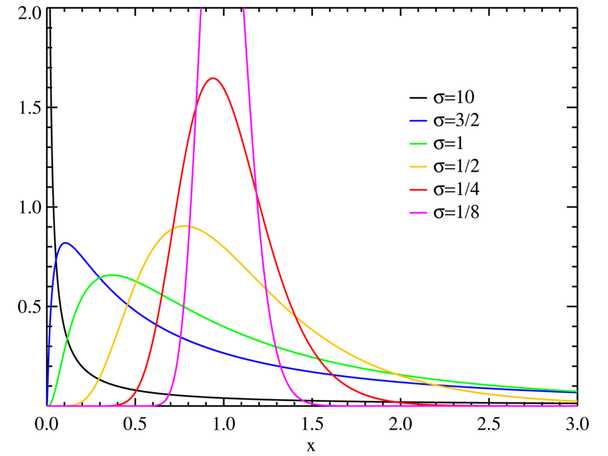

Wykres prrzedstawiono dla 𝜇 = 0  
Żródła:  
https://stat.ue.katowice.pl/stat11/logarytmiczno-normalny.html  
https://pl.wikipedia.org/wiki/Rozk%C5%82ad_logarytmicznie_normalny

# Wprowadzenie

W naszej pracy badamy własności estymatorów Metody Największej Wiarygodności rozkładu logarytmiczno - normalnego.

Celem naszego badania jest odpowiedzenie na następujące pytania:

- Jak zmienia się dokładność oszacowania w zależności od liczby danych, na podstawie których szacowane są parametry?
- Jak zmienia się kształt rozkładu (skośność, kurtoza) oszacowanych wartości parametrów w zależności od liczby danych, na podstawie których szacowane są parametry?
- Czy rozkład oszacowań parametrów jest rozkładem normalnym? jak to zależy od liczby danych?
- Czy zachowanie estymatorów MNW zależy od tego, który parametr rozkładu jest szacowany?
- Czy zachowanie estymatorów MNW różni się w zależności od rzeczywistej wartości szacowanego parametru?

Tworzymy funkcję, która estymuje parametry Metody Największej Wiarygodności dla rozkładu logarytmiczno-normalnego

```r
mnw_estimator_ln <- function(data) {
  fit_result <- fitdistr(data, "lognormal")
  return(c(meanlog = fit_result$estimate[1], sdlog = fit_result$estimate[2]))
}
```

Tworzymy funkcję, która losuje `n` danych z rozkładu logarytmiczno - normalnego, na podstawie których estymuje Metodą Największej Wiarygodności parametry rozkładu. Powtarza ten krok 500 razy, a dane zapisuje w ramce danych.

```r
simulate_mnw <- function(sample_sizes, true_params) {
  results <- data.frame(
    Nr = numeric(),
    True_MeanLog = numeric(),
    True_SDLog = numeric(),
    Estimated_MeanLog = numeric(),
    Estimated_SDLog = numeric(),
    Sample_Size = numeric()
  )

  for (n in sample_sizes) {
    for (i in 1:500) {
      simulated_data <- rlnorm(n, meanlog = true_params[1], sdlog = true_params[2])

      estimated_params <- mnw_estimator_ln(simulated_data)

      result_row <- data.frame(
        Nr = i,
        True_MeanLog = true_params[1],
        True_SDLog = true_params[2],
        Estimated_MeanLog = estimated_params[1],
        Estimated_SDLog = estimated_params[2],
        Sample_Size = n
      )

      results <- rbind(results, result_row)
    }
  }

  return(results)
}
```

Ustalamy wektor zawierający liczby danych, które będziemy losować z rozkładu :

```r
sample_sizes <- c(10, 20, 50, 100, 500, 1000)
```

# Badanie

## 𝜇 = 0, $\sigma$ = $\frac{1}{8}$

Ustalamy parametry rozkładu:

```r
true_params <- c(0, 0.125)
```

Wywołujemy funkcję dla różnej liczby próbek.

```r
simulation_results <- simulate_mnw(sample_sizes, true_params)
```

### Średnia logarytmu

Obliczamy statystyki opisowe dla wyestymowanych parametrów.

```r
summary_stats_meanlog <- simulation_results %>%
  group_by(Sample_Size) %>%
  summarise(
    Mean_MeanLog = mean(Estimated_MeanLog),
    SD_MeanLog = sd(Estimated_MeanLog),
    Kurtosis_MeanLog = kurtosis(Estimated_MeanLog),
    Skewness_MeanLog = skewness(Estimated_MeanLog),
    Shapiro_p_value = shapiro.test(Estimated_MeanLog)$p.value,
    Rozkład_normalny = ifelse(shapiro.test(Estimated_MeanLog)$p.value > 0.05, "Tak", "Nie")
  )

kable(summary_stats_meanlog, "markdown")
```

| Sample_Size | Mean_MeanLog | SD_MeanLog | Kurtosis_MeanLog | Skewness_MeanLog | Shapiro_p_value | Rozkład_normalny |
| --- | --- | --- | --- | --- | --- | --- |
| 10 | 0.0001788 | 0.0390017 | 3.190144 | -0.0789182 | 0.3806555 | Tak |
| 20 | -0.0012146 | 0.0268840 | 3.208779 | 0.0956497 | 0.3365952 | Tak |
| 50 | -0.0002473 | 0.0180093 | 2.778273 | 0.0078582 | 0.8928343 | Tak |
| 100 | 0.0004168 | 0.0129724 | 2.818114 | 0.0309648 | 0.6923712 | Tak |
| 500 | 0.0002564 | 0.0054769 | 3.349807 | -0.1192074 | 0.3963118 | Tak |
| 1000 | 0.0003286 | 0.0038109 | 2.933819 | -0.0018440 | 0.8148781 | Tak |

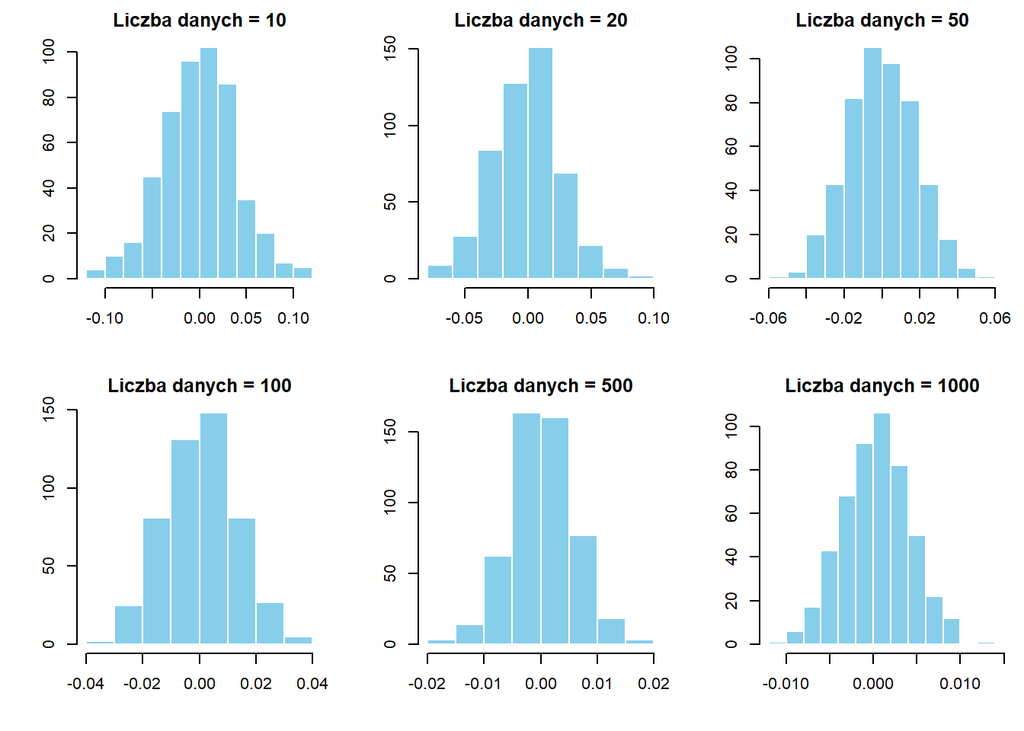

```r
par(mfrow = c(2, 3), mar = c(4, 4, 2, 1))

for (size in sample_sizes) {
  subset_data <- simulation_results[simulation_results$Sample_Size == size, ]

  hist(subset_data$Estimated_MeanLog, col = "skyblue", border = "white",
       main = paste("Liczba danych =", size), xlab = "", ylab = "")
}
```

Można zauważyć, że niezależnie od liczby danych największe skupienie danych obserwujemy w okolicy zera, a mniejsze w ogonach. Ponadto można dostrzec pewną symetrię w rozkładach.

Wykres pudełkowy:

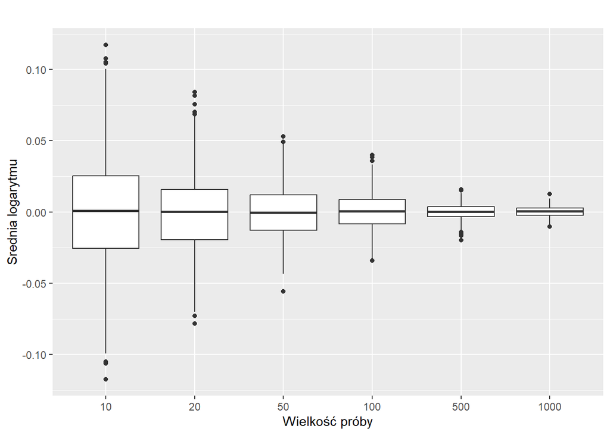

```r
ggplot(simulation_results, aes(x = as.factor(Sample_Size), y = Estimated_MeanLog)) +
  geom_boxplot() +
  labs(title = "",
       x = "Wielkość próby",
       y = "Srednia logarytmu")
```

Widzimy, że wraz ze wzrostem liczby danych, dokładność oszacowania paramteru wzrasta - wartości wyestymowanych estymatorów są coraz bardziej skumulowane wokół rzeczywistej wartości.

### Odchylenie standardowe logarytmu

Obliczmy statystyki opisowe dla wyestymowanych parametrów.

```r
summary_stats_sdlog <- simulation_results %>%
  group_by(Sample_Size) %>%
  summarise(
    Mean_SDLog = mean(Estimated_SDLog),
    SD_SDLog = sd(Estimated_SDLog),
    Kurtosis_SDLog = kurtosis(Estimated_SDLog),
    Skewness_SDLog = skewness(Estimated_SDLog),
    Shapiro_p_value = shapiro.test(Estimated_SDLog)$p.value,
    Rozkład_normalny = ifelse(shapiro.test(Estimated_SDLog)$p.value > 0.05, "Tak", "Nie")
  )

kable(summary_stats_sdlog, "markdown")
```

| Sample_Size | Mean_SDLog | SD_SDLog | Kurtosis_SDLog | Skewness_SDLog | Shapiro_p_value | Rozkład_normalny |
| --- | --- | --- | --- | --- | --- | --- |
| 10 | 0.1153775 | 0.0281235 | 3.016116 | 0.3400147 | 0.0008142 | Nie |
| 20 | 0.1204892 | 0.0193003 | 2.877823 | 0.2861166 | 0.0123215 | Nie |
| 50 | 0.1227987 | 0.0127422 | 3.215313 | 0.1422498 | 0.5587008 | Tak |
| 100 | 0.1240488 | 0.0093379 | 3.012399 | 0.0587797 | 0.7287037 | Tak |
| 500 | 0.1243485 | 0.0039903 | 2.823304 | 0.0957068 | 0.4639074 | Tak |
| 1000 | 0.1249390 | 0.0029422 | 2.890084 | 0.1721373 | 0.2563029 | Tak |

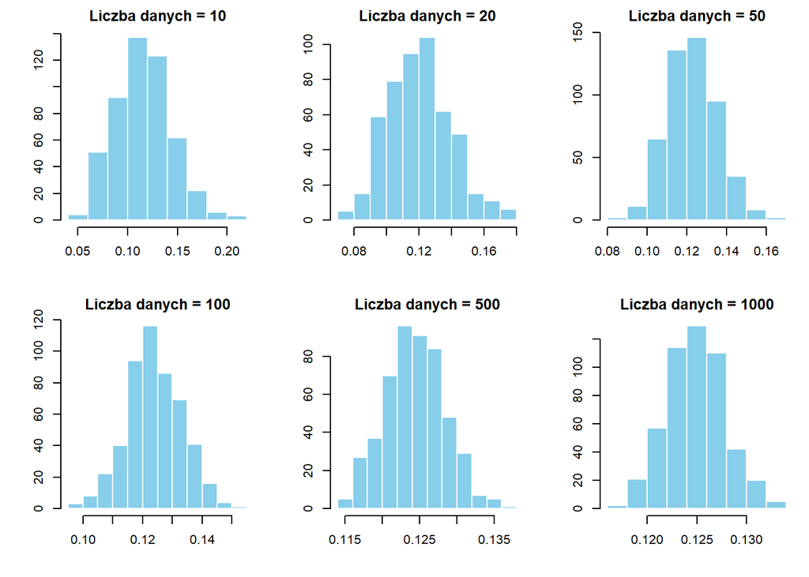

```r
par(mfrow = c(2, 3), mar = c(4, 4, 2, 1))

for (size in sample_sizes) {
  subset_data <- simulation_results[simulation_results$Sample_Size == size, ]

  hist(subset_data$Estimated_SDLog, col = "skyblue", border = "white",
       main = paste("Liczba danych =", size), xlab = "", ylab = "")
}
```

Znowu obserwujemy większe zagęszczenie danych wokół 0.125 (czyli rzeczywistej wartości estymowanego przez nas parametru), a mniejsze na brzegach rozkładu.  
*Wykres pudełkowy*:

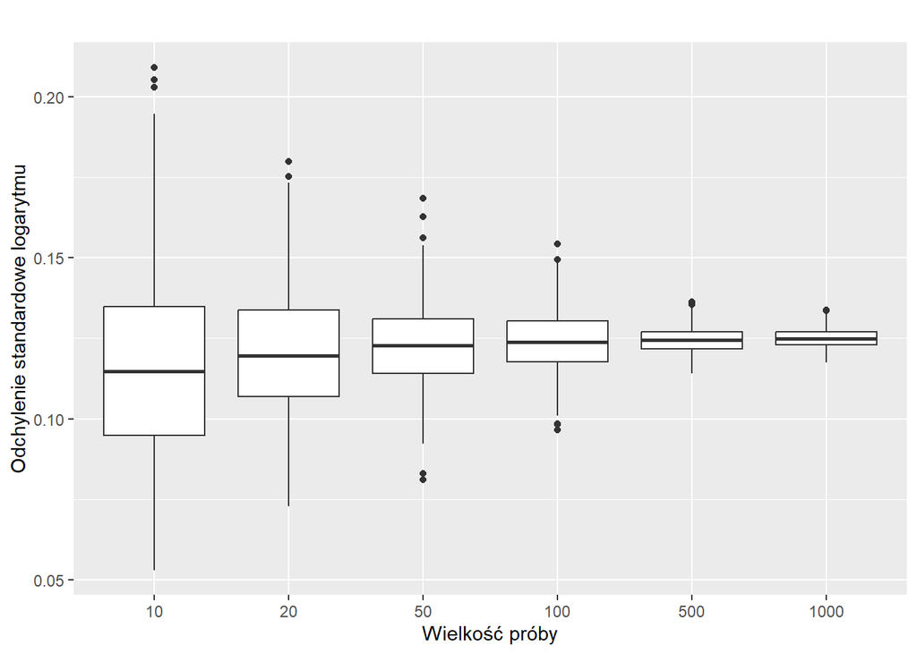

```r
ggplot(simulation_results, aes(x = as.factor(Sample_Size), y = Estimated_SDLog)) +
  geom_boxplot() +
  labs(title = "",
       x = "Wielkość próby",
       y = "Odchylenie standardowe logarytmu")
```

Znowu obserwujemy wzrost dokładności oszacowania wraz ze wzrostem liczby danych.

## 𝜇 = 0, $\sigma$ = 10

```r
true_params2 <- c(0, 10)
```

Wywołujemy funkcję dla różnej liczby próbek.

```r
simulation_results2 <- simulate_mnw(sample_sizes, true_params2)
```

### Średnia logarytmu

Obliczamy statystyki opisowe dla wyestymowanych parametrów.

```r
summary_stats_meanlog2 <- simulation_results2 %>%
  group_by(Sample_Size) %>%
  summarise(
    Mean_MeanLog = mean(Estimated_MeanLog),
    SD_MeanLog = sd(Estimated_MeanLog),
    Kurtosis_MeanLog = kurtosis(Estimated_MeanLog),
    Skewness_MeanLog = skewness(Estimated_MeanLog),
    Shapiro_p_value = shapiro.test(Estimated_MeanLog)$p.value,
    Rozkład_normalny = ifelse(shapiro.test(Estimated_MeanLog)$p.value > 0.05, "Tak", "Nie")
  )
kable(summary_stats_meanlog2, "markdown")
```

| Sample_Size | Mean_MeanLog | SD_MeanLog | Kurtosis_MeanLog | Skewness_MeanLog | Shapiro_p_value | Rozkład_normalny |
| --- | --- | --- | --- | --- | --- | --- |
| 10 | 0.0931004 | 3.1046029 | 3.120715 | 0.0323951 | 0.7258640 | Tak |
| 20 | 0.0036984 | 2.2666758 | 3.075909 | 0.0335860 | 0.4827853 | Tak |
| 50 | -0.1617150 | 1.3957397 | 3.398452 | 0.0524392 | 0.2910477 | Tak |
| 100 | -0.0742798 | 0.9707122 | 3.159441 | -0.0783007 | 0.8532615 | Tak |
| 500 | -0.0102866 | 0.4576294 | 3.247876 | -0.1745349 | 0.1051781 | Tak |
| 1000 | -0.0052276 | 0.3034161 | 2.905879 | 0.0038065 | 0.9321844 | Tak |

Znowu widzimy, że niezależnie od ilości danych rozkłady przypominają rozkład normalny - kurtoza bliska 3, niska skośność. Wyniki testu Shapiro - Wilka potwierdzają, że cechy mają rozkład normalny.  
Zobaczmy, jak wyniki badania prezentują się na *histogramach*:

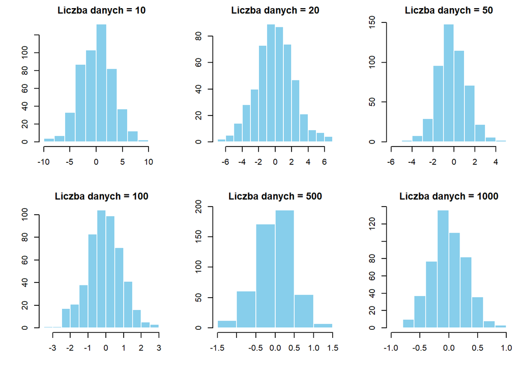

```r
par(mfrow = c(2, 3), mar = c(4, 4, 2, 1))

for (size in sample_sizes) {
  subset_data2 <- simulation_results2[simulation_results2$Sample_Size == size, ]

  hist(subset_data2$Estimated_MeanLog, col = "skyblue", border = "white",
       main = paste("Liczba danych =", size), xlab = "", ylab = "")
}
```

Podobnie jak wcześniej - mozna zauważyć dużą koncentrację danych wokół 0 oraz niską na brzegach.  
*Wykres pudełkowy*:

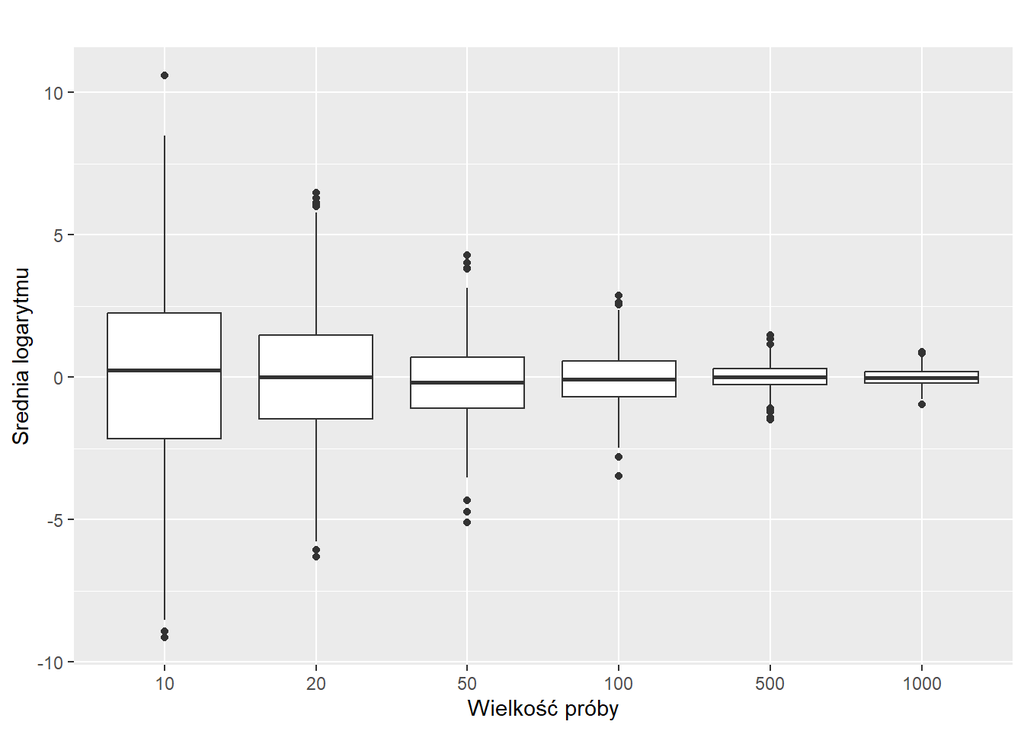

```r
ggplot(simulation_results2, aes(x = as.factor(Sample_Size), y = Estimated_MeanLog)) +
  geom_boxplot() +
  labs(title = "",
       x = "Wielkość próby",
       y = "Srednia logarytmu")
```

Tutaj znowu obserwujemy zwiększenie dokładności oszacowania wraz ze wzrostem liczby danych.

### Odchylenie standardowe logarytmu

Obliczamy statystyki opisowe dla wyestymowanych parametrów.

```r
summary_stats_sdlog3 <- simulation_results2 %>%
  group_by(Sample_Size) %>%
  summarise(
    Mean_SDLog = mean(Estimated_SDLog),
    SD_SDLog = sd(Estimated_SDLog),
    Kurtosis_SDLog = kurtosis(Estimated_SDLog),
    Skewness_SDLog = skewness(Estimated_SDLog),
    Shapiro_p_value = shapiro.test(Estimated_SDLog)$p.value,
    Rozkład_normalny = ifelse(shapiro.test(Estimated_SDLog)$p.value > 0.05, "Tak", "Nie")
  )

kable(summary_stats_sdlog3, "markdown")
```

| Sample_Size | Mean_SDLog | SD_SDLog | Kurtosis_SDLog | Skewness_SDLog | Shapiro_p_value | Rozkład_normalny |
| --- | --- | --- | --- | --- | --- | --- |
| 10 | 9.217126 | 2.2047183 | 3.324560 | 0.2675808 | 0.0609587 | Tak |
| 20 | 9.678161 | 1.5454496 | 2.634593 | 0.0980149 | 0.1612867 | Tak |
| 50 | 9.884468 | 1.0300541 | 2.681403 | 0.2017033 | 0.0058536 | Nie |
| 100 | 9.919202 | 0.6652843 | 2.826915 | -0.0549974 | 0.7662815 | Tak |
| 500 | 9.983988 | 0.3367746 | 2.762947 | -0.0188827 | 0.6169970 | Tak |
| 1000 | 9.985245 | 0.2205844 | 3.294456 | -0.0655032 | 0.7659607 | Tak |

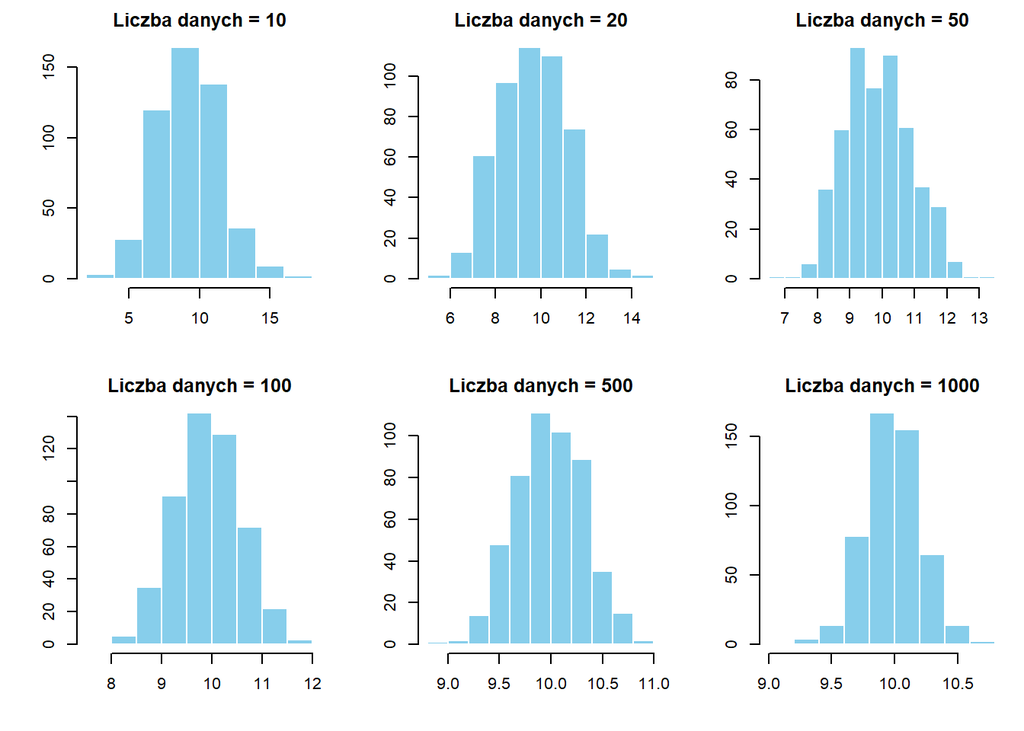

```r
par(mfrow = c(2, 3), mar = c(4, 4, 2, 1))

for (size in sample_sizes) {
  subset_data3 <- simulation_results2[simulation_results2$Sample_Size == size, ]

  hist(subset_data3$Estimated_SDLog, col = "skyblue", border = "white",
       main = paste("Liczba danych =", size), xlab = "", ylab = "")
}
```

Widzimy duże zagęszczenie danych wokół 10 w każdym przypadku, a małe zagęszczenie po brzegach. *Wykres pudełkowy:*

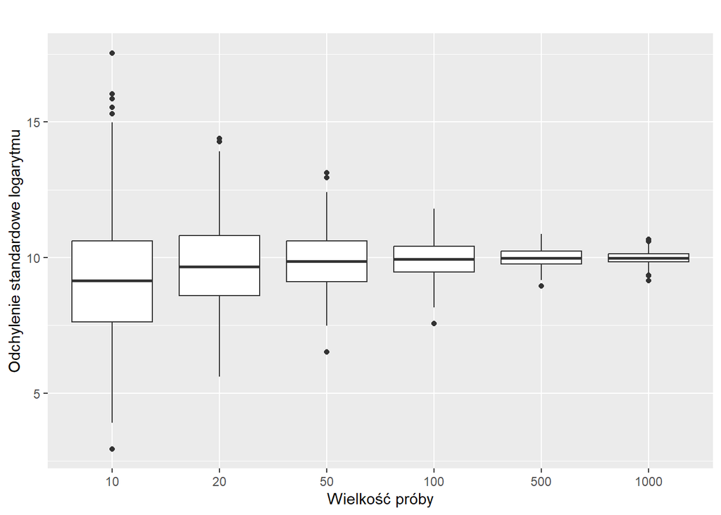

```r
ggplot(simulation_results2, aes(x = as.factor(Sample_Size), y = Estimated_SDLog)) +
  geom_boxplot() +
  labs(title = "",
       x = "Wielkość próby",
       y = "Odchylenie standardowe logarytmu")
```

Znowu widzimy, że wraz ze wzrostem liczby danych, wartości estymatorów są coraz mocniej skumulowane wokół rzeczywistej wartości $\sigma$.

## 𝜇 = 0, $\sigma$ = 1

```r
true_params3 <- c(0, 1)
```

Wywołujemy funkcję dla różnej liczby próbek.

```r
simulation_results3<- simulate_mnw(sample_sizes, true_params3)
```

### Średnia logarytmu

Obliczamy statystyki opisowe dla wyestymowanych parametrów.

```r
summary_stats_meanlog4 <- simulation_results3 %>%
  group_by(Sample_Size) %>%
  summarise(
    Mean_MeanLog = mean(Estimated_MeanLog),
    SD_MeanLog = sd(Estimated_MeanLog),
    Kurtosis_MeanLog = kurtosis(Estimated_MeanLog),
    Skewness_MeanLog = skewness(Estimated_MeanLog),
    Shapiro_p_value = shapiro.test(Estimated_MeanLog)$p.value,
    Rozkład_normalny = ifelse(shapiro.test(Estimated_MeanLog)$p.value > 0.05, "Tak", "Nie")
  )

kable(summary_stats_meanlog4, "markdown")
```

| Sample_Size | Mean_MeanLog | SD_MeanLog | Kurtosis_MeanLog | Skewness_MeanLog | Shapiro_p_value | Rozkład_normalny |
| --- | --- | --- | --- | --- | --- | --- |
| 10 | 0.0047921 | 0.3082710 | 3.054769 | -0.1239541 | 0.4271772 | Tak |
| 20 | 0.0024336 | 0.2272972 | 2.964093 | -0.0861517 | 0.2708320 | Tak |
| 50 | -0.0020293 | 0.1463127 | 2.928213 | -0.0491075 | 0.9736836 | Tak |
| 100 | 0.0050415 | 0.0980617 | 3.314499 | -0.0970592 | 0.4729244 | Tak |
| 500 | -0.0026858 | 0.0436924 | 3.230487 | 0.2019860 | 0.1873229 | Tak |
| 1000 | -0.0007832 | 0.0319856 | 3.121695 | -0.0843602 | 0.8396800 | Tak |

Niezależnie od liczby danych estymatory mają rozkład normalny i są zbliżone do rzeczywistej wartości parametru.Im więcej mamy danych, tym odchylenie standardowe jest mniejsze, zatem wartości są mniej zróżnicowane.  
Zobaczmy, jak wyniki badania prezentują się na *histogramach*:

[figure not shown]

```r
par(mfrow = c(2, 3), mar = c(4, 4, 2, 1))

for (size in sample_sizes) {
  subset_data4 <- simulation_results3[simulation_results3$Sample_Size == size, ]

  hist(subset_data3$Estimated_MeanLog, col = "skyblue", border = "white",
       main = paste("Liczba danych =", size), xlab = "", ylab = "")
}
```

Największe zagęszczenie jest wokół zera, niskie zagęszczenie danych obserwujemy na brzegach.  
*Wykres pudełkowy:*

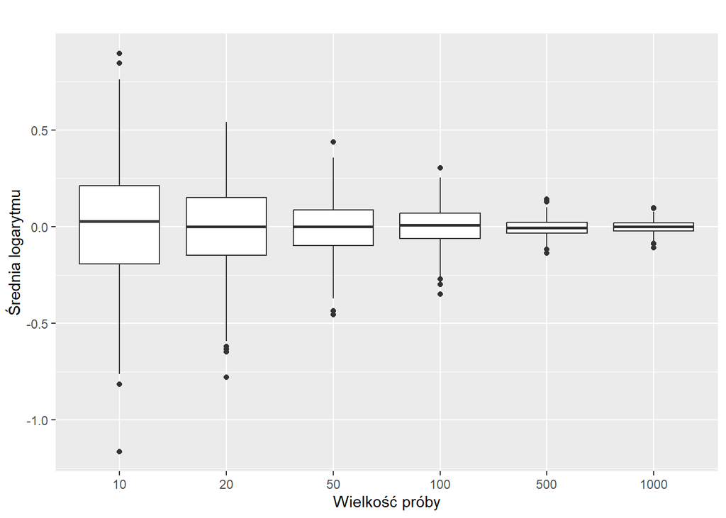

```r
ggplot(simulation_results3, aes(x = as.factor(Sample_Size), y = Estimated_MeanLog)) +
  geom_boxplot() +
  labs(title = "",
       x = "Wielkość próby",
       y = "Średnia logarytmu")
```

Znowu dokładność dopasowania wzrasta wzraz ze wzrostem liczby danych.

### Odchylenie standardowe logarytmu

Obliczamy statystyki opisowe dla wyestymowanych parametrów.

```r
summary_stats_sdlog5 <- simulation_results3 %>%
  group_by(Sample_Size) %>%
  summarise(
    Mean_SDLog = mean(Estimated_SDLog),
    SD_SDLog = sd(Estimated_SDLog),
    Kurtosis_SDLog = kurtosis(Estimated_SDLog),
    Skewness_SDLog = skewness(Estimated_SDLog),
    Shapiro_p_value = shapiro.test(Estimated_SDLog)$p.value,
    Rozkład_normalny = ifelse(shapiro.test(Estimated_SDLog)$p.value > 0.05, "Tak", "Nie")
  )
kable(summary_stats_sdlog5, "markdown")
```

| Sample_Size | Mean_SDLog | SD_SDLog | Kurtosis_SDLog | Skewness_SDLog | Shapiro_p_value | Rozkład_normalny |
| --- | --- | --- | --- | --- | --- | --- |
| 10 | 0.9254150 | 0.2130001 | 2.784943 | 0.1318935 | 0.2676744 | Tak |
| 20 | 0.9681029 | 0.1508169 | 3.008785 | 0.1484802 | 0.4659663 | Tak |
| 50 | 0.9825077 | 0.0945538 | 3.157814 | 0.1222086 | 0.5551921 | Tak |
| 100 | 0.9951525 | 0.0724159 | 3.076355 | 0.1445929 | 0.0070943 | Nie |
| 500 | 0.9964596 | 0.0320728 | 2.922292 | -0.1878580 | 0.0595184 | Tak |
| 1000 | 0.9993744 | 0.0230148 | 2.924956 | -0.0712916 | 0.9857358 | Tak |

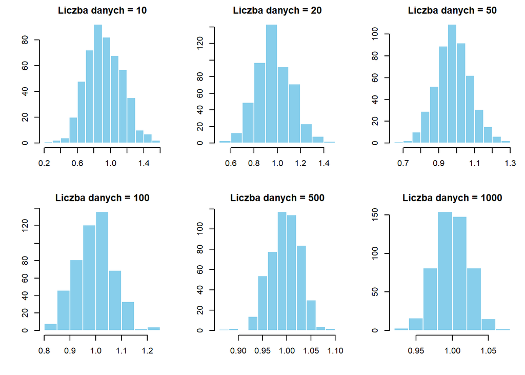

```r
par(mfrow = c(2, 3), mar = c(4, 4, 2, 1))

for (size in sample_sizes) {
  subset_data5 <- simulation_results3[simulation_results3$Sample_Size == size, ]

  hist(subset_data5$Estimated_SDLog, col = "skyblue", border = "white",
       main = paste("Liczba danych =", size), xlab = "", ylab = "")
}
```

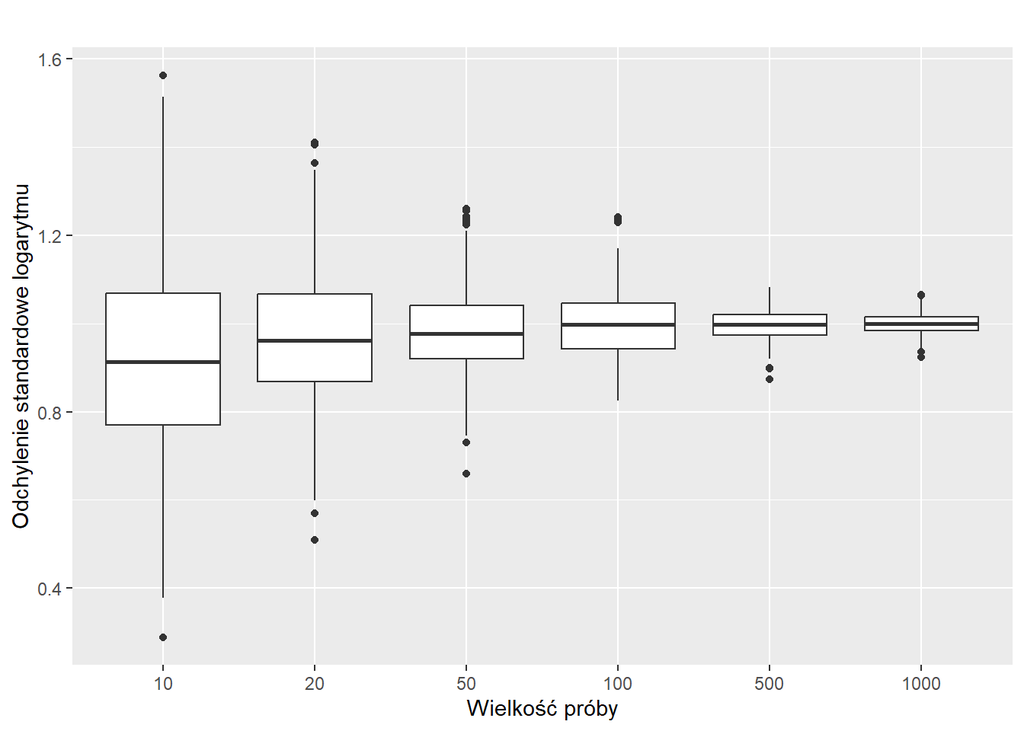

```r
ggplot(simulation_results3, aes(x = as.factor(Sample_Size), y = Estimated_SDLog)) +
  geom_boxplot() +
  labs(title = "",
       x = "Wielkość próby",
       y = "Odchylenie standardowe logarytmu")
```

Wraz ze wzrostem liczby danych, wyniki coraz bardziej skupiają się wokół rzeczywistej wartości estymowanego parametru

## 𝜇 = -3, $\sigma$ = 1

```r
true_params4 <- c(-3, 1)
```

Wywołujemy funkcję dla różnej liczby próbek.

```r
simulation_results4<- simulate_mnw(sample_sizes, true_params4)
```

### Średnia logarytmu

Obliczamy statystyki opisowe dla wyestymowanych parametrów.

```r
summary_stats_meanlog6 <- simulation_results4 %>%
  group_by(Sample_Size) %>%
  summarise(
    Mean_MeanLog = mean(Estimated_MeanLog),
    SD_MeanLog = sd(Estimated_MeanLog),
    Kurtosis_MeanLog = kurtosis(Estimated_MeanLog),
    Skewness_MeanLog = skewness(Estimated_MeanLog),
    Shapiro_p_value = shapiro.test(Estimated_MeanLog)$p.value,
    Rozkład_normalny = ifelse(shapiro.test(Estimated_MeanLog)$p.value > 0.05, "Tak", "Nie")
  )
kable(summary_stats_meanlog6, "markdown")
```

| Sample_Size | Mean_MeanLog | SD_MeanLog | Kurtosis_MeanLog | Skewness_MeanLog | Shapiro_p_value | Rozkład_normalny |
| --- | --- | --- | --- | --- | --- | --- |
| 10 | -3.024015 | 0.3120792 | 3.359202 | -0.1835383 | 0.0546808 | Tak |
| 20 | -2.980758 | 0.2242799 | 3.454607 | -0.0088349 | 0.3870765 | Tak |
| 50 | -2.995769 | 0.1454109 | 2.928930 | -0.1223383 | 0.8327291 | Tak |
| 100 | -2.999903 | 0.0968526 | 3.090752 | 0.0056331 | 0.8606558 | Tak |
| 500 | -3.002454 | 0.0440754 | 3.493298 | -0.0882608 | 0.0380951 | Nie |
| 1000 | -2.999332 | 0.0330087 | 2.744410 | -0.2262889 | 0.0174748 | Nie |

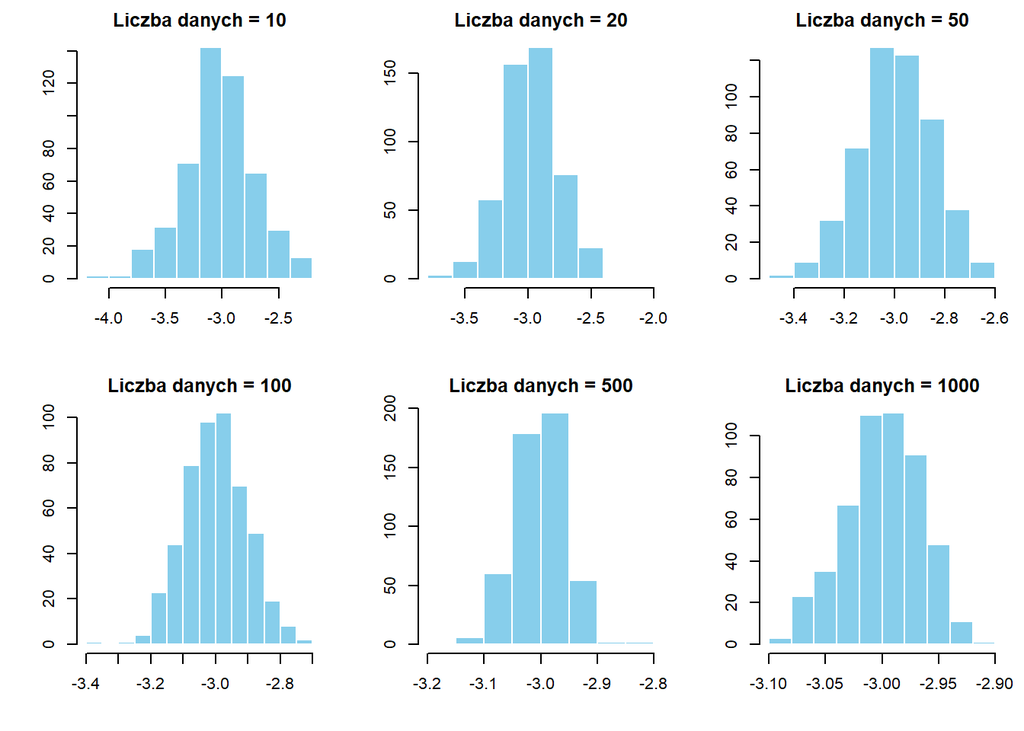

```r
par(mfrow = c(2, 3), mar = c(4, 4, 2, 1))

for (size in sample_sizes) {
  subset_data6 <- simulation_results4[simulation_results4$Sample_Size == size, ]

  hist(subset_data6$Estimated_MeanLog, col = "skyblue", border = "white",
       main = paste("Liczba danych =", size), xlab = "", ylab = "")
}
```

Niezależnie od liczby danych widzimy duże zagęszczenie danych wokół -3 (rzeczywistej wartości średniej logarytmu).  
*Wykres pudełkowy*:

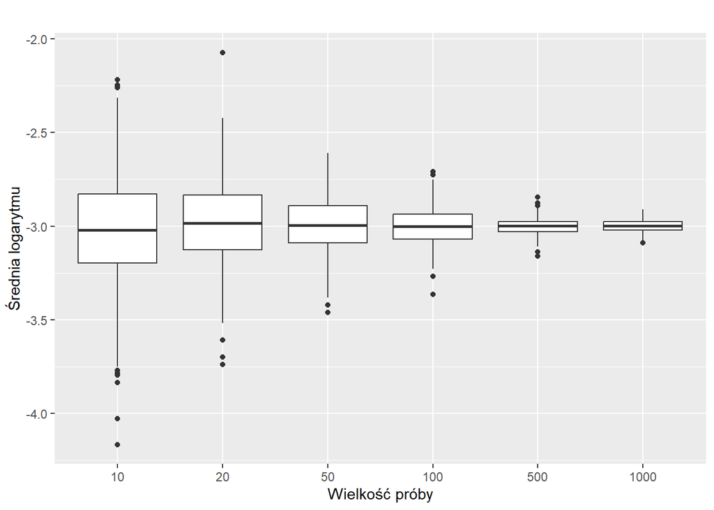

```r
ggplot(simulation_results4, aes(x = as.factor(Sample_Size), y = Estimated_MeanLog)) +
  geom_boxplot() +
  labs(title = "",
       x = "Wielkość próby",
       y = "Średnia logarytmu")
```

Wraz ze wzrostem liczby danych rozkłady wyestymowanych parametrów są mocniej skupione wokół -3.

### Odchylenie standardowe logarytmu

Obliczamy statystyki opisowe dla wyestymowanych parametrów.

```r
summary_stats_sdlog7 <- simulation_results4 %>%
  group_by(Sample_Size) %>%
  summarise(
    Mean_SDLog = mean(Estimated_SDLog),
    SD_SDLog = sd(Estimated_SDLog),
    Kurtosis_SDLog = kurtosis(Estimated_SDLog),
    Skewness_SDLog = skewness(Estimated_SDLog),
    Shapiro_p_value = shapiro.test(Estimated_SDLog)$p.value,
    Rozkład_normalny = ifelse(shapiro.test(Estimated_SDLog)$p.value > 0.05, "Tak", "Nie")
  )
kable(summary_stats_sdlog7, "markdown")
```

| Sample_Size | Mean_SDLog | SD_SDLog | Kurtosis_SDLog | Skewness_SDLog | Shapiro_p_value | Rozkład_normalny |
| --- | --- | --- | --- | --- | --- | --- |
| 10 | 0.9230833 | 0.2226910 | 2.885926 | 0.2365881 | 0.0337741 | Nie |
| 20 | 0.9574283 | 0.1546524 | 3.093270 | 0.3430457 | 0.0049292 | Nie |
| 50 | 0.9858150 | 0.1016105 | 2.765020 | 0.0126173 | 0.6416781 | Tak |
| 100 | 0.9896788 | 0.0715080 | 3.181888 | 0.1637357 | 0.1244768 | Tak |
| 500 | 0.9988114 | 0.0322533 | 3.452115 | -0.1250675 | 0.3762477 | Tak |
| 1000 | 1.0010517 | 0.0225149 | 2.718813 | 0.0443765 | 0.4958408 | Tak |

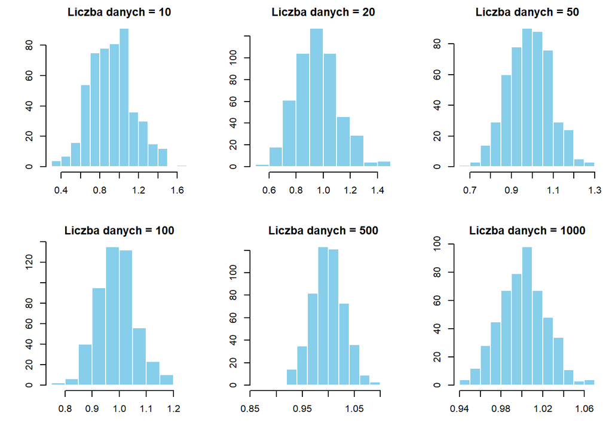

```r
par(mfrow = c(2, 3), mar = c(4, 4, 2, 1))

for (size in sample_sizes) {
  subset_data7 <- simulation_results4[simulation_results4$Sample_Size == size, ]

  hist(subset_data7$Estimated_SDLog, col = "skyblue", border = "white",
       main = paste("Liczba danych =", size), xlab = "", ylab = "")
}
```

Widać duże skoncentrowanie danych wokół 1.  
*Wykres pudełkowy*:

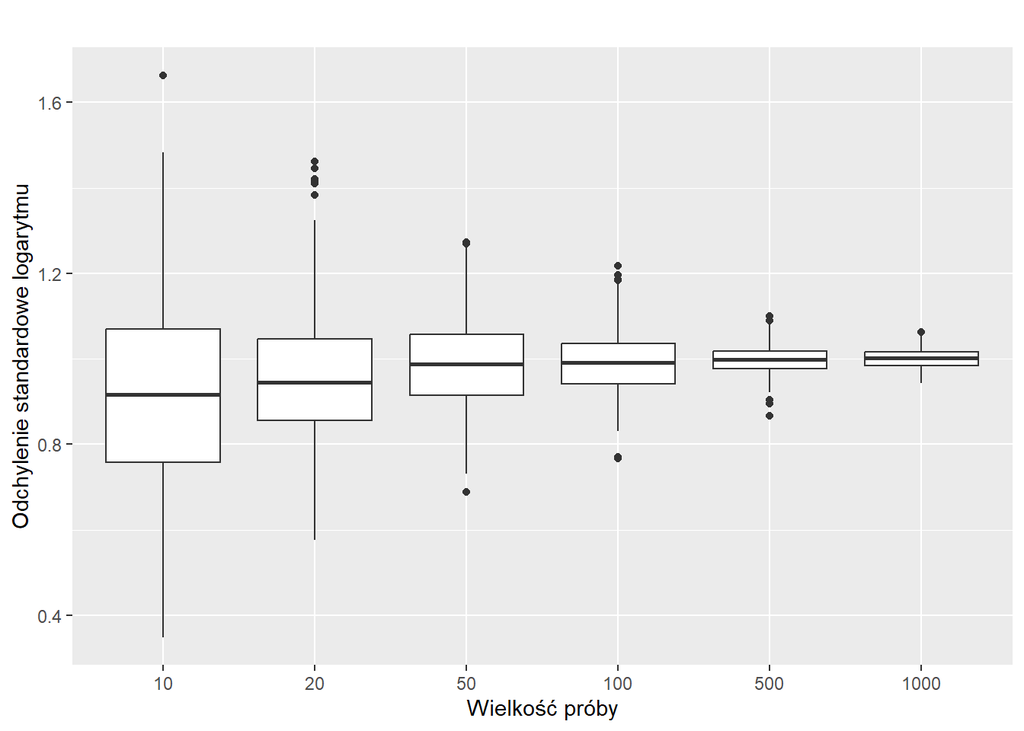

```r
ggplot(simulation_results4, aes(x = as.factor(Sample_Size), y = Estimated_SDLog)) +
  geom_boxplot() +
  labs(title = "",
       x = "Wielkość próby",
       y = "Odchylenie standardowe logarytmu")
```

Wraz ze wzrostem danych rozkłady oszacowanych estymatorów są coraz bardziej skupione wokół rzeczywistej wartości odchylenia standardowego logarytmu.

## 𝜇 = 5, $\sigma$ = 1

```r
true_params5 <- c(5, 1)
```

Wywołujemy funkcję dla różnej liczby próbek.

```r
simulation_results5<- simulate_mnw(sample_sizes, true_params5)
```

### Średnia logarytmu

Obliczamy statystyki opisowe dla wyestymowanych parametrów.

```r
summary_stats_meanlog8 <- simulation_results5 %>%
  group_by(Sample_Size) %>%
  summarise(
    Mean_MeanLog = mean(Estimated_MeanLog),
    SD_MeanLog = sd(Estimated_MeanLog),
    Kurtosis_MeanLog = kurtosis(Estimated_MeanLog),
    Skewness_MeanLog = skewness(Estimated_MeanLog),
    Shapiro_p_value = shapiro.test(Estimated_MeanLog)$p.value,
    Rozkład_normalny = ifelse(shapiro.test(Estimated_MeanLog)$p.value > 0.05, "Tak", "Nie")
  )
kable(summary_stats_meanlog8, "markdown")
```

| Sample_Size | Mean_MeanLog | SD_MeanLog | Kurtosis_MeanLog | Skewness_MeanLog | Shapiro_p_value | Rozkład_normalny |
| --- | --- | --- | --- | --- | --- | --- |
| 10 | 5.011676 | 0.3143725 | 2.907071 | 0.2568243 | 0.0541251 | Tak |
| 20 | 5.009724 | 0.2173994 | 2.866963 | 0.1088089 | 0.6865273 | Tak |
| 50 | 4.999811 | 0.1444846 | 3.077301 | -0.3108747 | 0.0064959 | Nie |
| 100 | 4.996221 | 0.0977688 | 2.944077 | -0.1379301 | 0.6183951 | Tak |
| 500 | 5.000169 | 0.0456189 | 2.918886 | 0.1188221 | 0.6978740 | Tak |
| 1000 | 4.999325 | 0.0322157 | 2.968377 | -0.1430695 | 0.2122836 | Tak |

Widzimy, że dla n = 50 wynik p_value zmusza do odrzucenia hipotezy o normalności rozkładu. Jednakże podobnie jak w poprzednim przypadku - wartość kurtozy jest bliska 3, a obliczona skośność ma niską wartość, co wskazuje na symetryczność rozkładu.  
Zobaczmy, jak wyniki badania prezentują się na *histogramach*:

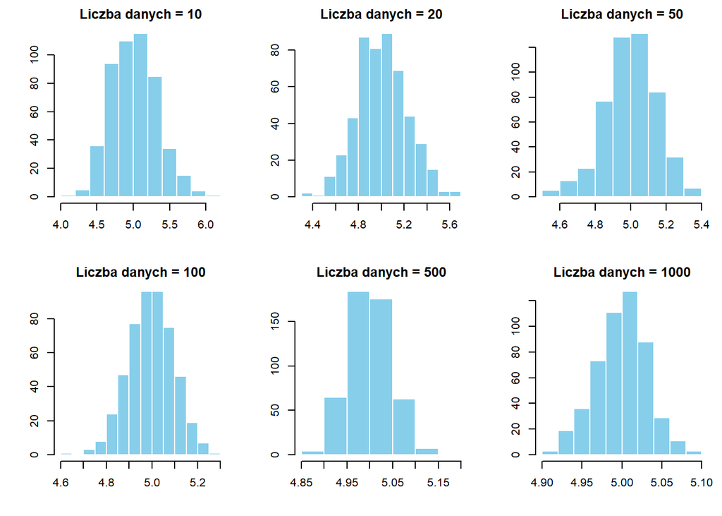

```r
par(mfrow = c(2, 3), mar = c(4, 4, 2, 1))

for (size in sample_sizes) {
  subset_data8 <- simulation_results5[simulation_results5$Sample_Size == size, ]

  hist(subset_data8$Estimated_MeanLog, col = "skyblue", border = "white",
       main = paste("Liczba danych =", size), xlab = "", ylab = "")
}
```

Dane mocno skupione wokół 5 - rzeczywistej wartości estymowanego parametru.  
*Wykres pudełkowy*:

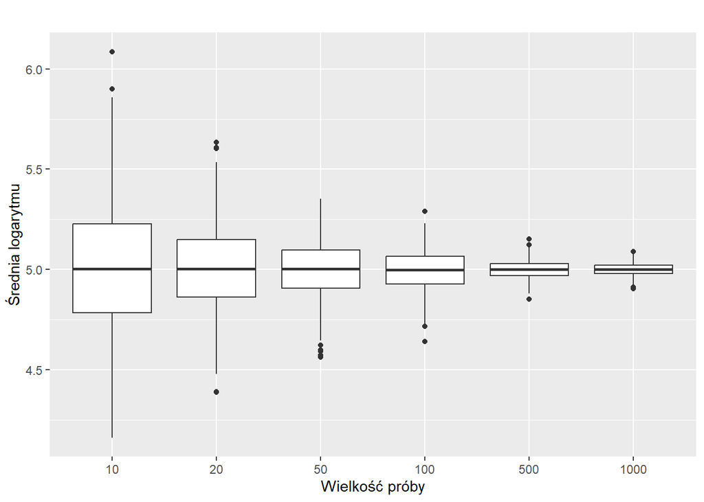

```r
ggplot(simulation_results5, aes(x = as.factor(Sample_Size), y = Estimated_MeanLog)) +
  geom_boxplot() +
  labs(title = "",
       x = "Wielkość próby",
       y = "Średnia logarytmu")
```

Wraz ze wzrostem danych zwiększa się dokładność oszacowań średniej logarytmu.

### Odchylenie standardowe logarytmu

Obliczmay statystyki opisowe dla wyestymowanych parametrów.

```r
summary_stats_sdlog9 <- simulation_results5 %>%
  group_by(Sample_Size) %>%
  summarise(
    Mean_SDLog = mean(Estimated_SDLog),
    SD_SDLog = sd(Estimated_SDLog),
    Kurtosis_SDLog = kurtosis(Estimated_SDLog),
    Skewness_SDLog = skewness(Estimated_SDLog),
    Shapiro_p_value = shapiro.test(Estimated_SDLog)$p.value,
    Rozkład_normalny = ifelse(shapiro.test(Estimated_SDLog)$p.value > 0.05, "Tak", "Nie")
  )
kable(summary_stats_sdlog9, "markdown")
```

| Sample_Size | Mean_SDLog | SD_SDLog | Kurtosis_SDLog | Skewness_SDLog | Shapiro_p_value | Rozkład_normalny |
| --- | --- | --- | --- | --- | --- | --- |
| 10 | 0.9064207 | 0.2227423 | 2.560002 | 0.0882441 | 0.1285061 | Tak |
| 20 | 0.9590081 | 0.1526804 | 2.828089 | -0.0485601 | 0.6933939 | Tak |
| 50 | 0.9874553 | 0.1004580 | 2.962129 | 0.0731821 | 0.6024435 | Tak |
| 100 | 0.9943686 | 0.0687092 | 3.164969 | -0.0584853 | 0.7622864 | Tak |
| 500 | 0.9977198 | 0.0309444 | 2.840826 | 0.0279795 | 0.8167376 | Tak |
| 1000 | 0.9998704 | 0.0225218 | 3.641039 | -0.0876359 | 0.1025792 | Tak |

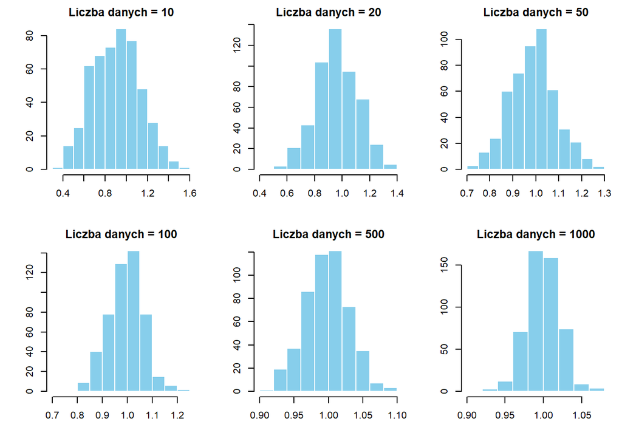

```r
par(mfrow = c(2, 3), mar = c(4, 4, 2, 1))

for (size in sample_sizes) {
  subset_data9 <- simulation_results5[simulation_results5$Sample_Size == size, ]

  hist(subset_data9$Estimated_SDLog, col = "skyblue", border = "white",
       main = paste("Liczba danych =", size), xlab = "", ylab = "")
}
```

Dane są skupione wokół 1 - rzeczywistej wartości szacowanego parametru.  
*Wykres pudełkowy*:

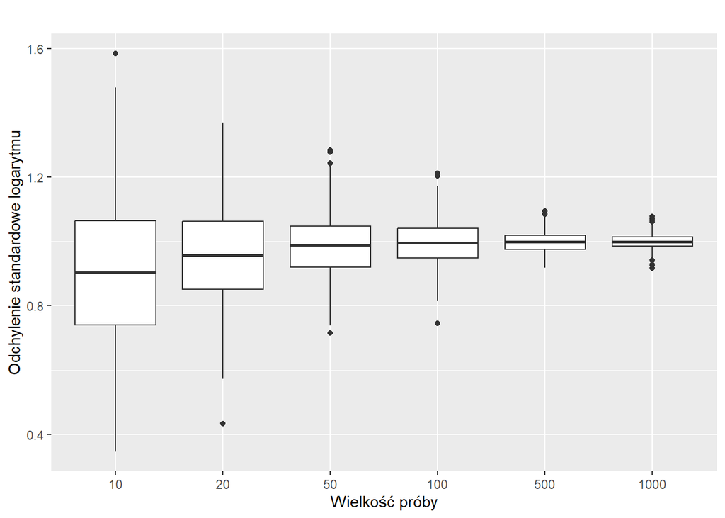

```r
ggplot(simulation_results5, aes(x = as.factor(Sample_Size), y = Estimated_SDLog)) +
  geom_boxplot() +
  labs(title = "",
       x = "Wielkość próby",
       y = "Odchylenie standardowe logarytmu")
```

Tutaj widzimy, że wraz ze wzrostem liczby danych, dokładność oszacowania paramteru wzrasta - wartości wyestymowanych estymatorów są coraz bardziej skumulowane wokół jego rzeczywistej wartości. $\sigma$

# Podsumowanie

- **Dokładność estymacji wzrasta wraz ze wzrostem liczby danych**: Badanie wykazało, że w miarę zwiększania liczby danych estymatory MNW były coraz bardziej skumulowane wokół rzeczywistych wartości parametrów (szczególnie dobrze pokazywały to wykresy pudełkowe). Dla małych próbek mieliśmy mniejszą dokładność, ale w miarę wzrostu próbki estymacje stawały się bardziej precyzyjne.
- **Kształt rozkładu estymatorów**: W większości przypadków rozkłady estymatorów dla obu parametrów (średniej logarytmu i odchylenia standardowego logarytmu) wykazywały podobieństwo do rozkładu normalnego. Testy statystyczne potwierdzały, że w większości przypadków można założyć normalność tych rozkładów.
- **Zależność dokładności od rzeczywistej wartości szacowanego parametru**: Nie zaobserwowaliśmy znaczących różnic w zachowaniu estymatorów MNW w zależności od konkretnych wartości rzeczywistych parametrów rozkładu. Dokładność estymacji wydaje się być stabilna w różnych scenariuszach.
- **Zachowanie estymatorów MNW nie zależy od tego, który parametr jest estymowany**: We wszystkich przypadkach dochodziliśmy do bardzo podobnych wniosków.
- **Testy normalności**: W niektórych przypadkach testy normalności wskazywały na potencjalne odstępstwa od normalności, zwłaszcza dla mniejszych próbek. Niemniej jednak, analiza kurtozy i skośności oraz ocena histogramów sugerują, że różnice te mogą być niewielkie. W zdecydowanej większości przypadków rozkład oszacowań parametrów był rozkładem normalnym.